# Project: Wrangle and Analyze Data

```python
# taking care of imports
import pandas as pd
import requests
import json
import re
import matplotlib.pyplot as plt
```

```python
# tweepy data (the empty strings should be replaced with actual data)
# import tweepy

# consumer_key = ''
# consumer_secret = ''
# access_token = ''
# access_secret = ''

# auth = tweepy.OAuthHandler(consumer_key, consumer_secret)
# auth.set_access_token(access_token, access_secret)

# api = tweepy.API(auth,wait_on_rate_limit = True)
```

## 1. Gathering Data for this Project

### 1.1 The we rate dogs twitter archive

```python
# reading the downloaded data
df_twitt_arch = pd.read_csv('twitter-archive-enhanced.csv')
#displaying first 3 rows
df_twitt_arch.head(3)
```

|  | tweet_id | in_reply_to_status_id | in_reply_to_user_id | timestamp | source | text | retweeted_status_id | retweeted_status_user_id | retweeted_status_timestamp | expanded_urls | rating_numerator | rating_denominator | name | doggo | floofer | pupper | puppo |
| --- | --- | --- | --- | --- | --- | --- | --- | --- | --- | --- | --- | --- | --- | --- | --- | --- | --- |
| 0 | 892420643555336193 | NaN | NaN | 2017-08-01 16:23:56 +0000 | <a href="http://twitter.com/download/iphone" r... | This is Phineas. He's a mystical boy. Only eve... | NaN | NaN | NaN | https://twitter.com/dog_rates/status/892420643... | 13 | 10 | Phineas | None | None | None | None |
| 1 | 892177421306343426 | NaN | NaN | 2017-08-01 00:17:27 +0000 | <a href="http://twitter.com/download/iphone" r... | This is Tilly. She's just checking pup on you.... | NaN | NaN | NaN | https://twitter.com/dog_rates/status/892177421... | 13 | 10 | Tilly | None | None | None | None |
| 2 | 891815181378084864 | NaN | NaN | 2017-07-31 00:18:03 +0000 | <a href="http://twitter.com/download/iphone" r... | This is Archie. He is a rare Norwegian Pouncin... | NaN | NaN | NaN | https://twitter.com/dog_rates/status/891815181... | 12 | 10 | Archie | None | None | None | None |

### 1.2 The tweet image predictions

```python
# "get" - ing the file
response = requests.get('https://d17h27t6h515a5.cloudfront.net/topher/2017/August/599fd2ad_image-predictions/image-predictions.tsv')
# saving the response to file
with open('image_predictions.tsv', 'a') as file:
    file.write(response.text)

df_img_pred = pd.read_csv('image_predictions.tsv', sep='\t')
df_img_pred.head(3)
```

|  | tweet_id | jpg_url | img_num | p1 | p1_conf | p1_dog | p2 | p2_conf | p2_dog | p3 | p3_conf | p3_dog |
| --- | --- | --- | --- | --- | --- | --- | --- | --- | --- | --- | --- | --- |
| 0 | 666020888022790149 | https://pbs.twimg.com/media/CT4udn0WwAA0aMy.jpg | 1 | Welsh_springer_spaniel | 0.465074 | True | collie | 0.156665 | True | Shetland_sheepdog | 0.0614285 | True |
| 1 | 666029285002620928 | https://pbs.twimg.com/media/CT42GRgUYAA5iDo.jpg | 1 | redbone | 0.506826 | True | miniature_pinscher | 0.07419169999999999 | True | Rhodesian_ridgeback | 0.07201 | True |
| 2 | 666033412701032449 | https://pbs.twimg.com/media/CT4521TWwAEvMyu.jpg | 1 | German_shepherd | 0.596461 | True | malinois | 0.13858399999999998 | True | bloodhound | 0.11619700000000001 | True |

```python
# getting the information from twitter
# this part is commented out, as it will not work without the actual api data
# for tweet_id in df_twitt_arch.tweet_id:
#     try:
#         tweet = api.get_status(tweet_id)
#         with open('tweet_json.txt', 'a') as file:
#             json.dump(tweet._json, file)
#             file.write('\n')
#     except:
#         pass
```

```python
# reading the tweets
tweets = []
for line in open('tweet_json.txt', 'r'):
    tweets.append(json.loads(line))
```

```python
# checking if we actually have the data
tweets[0]['retweet_count']
```

```
7716
```

```python
# building a dictionary of tweets
dict_tweets = {}
for tweet in tweets:
    dict_tweets[tweet['id']] = [tweet['retweet_count'], tweet['favorite_count']]

# buidling the dataframe from tweets
df_tweets = pd.DataFrame.from_dict(dict_tweets, orient = 'index', columns=['retweet_count', 'favorite_count'])
df_tweets.sample(5)
```

|  | retweet_count | favorite_count |
| --- | --- | --- |
| 703382836347330562 | 1144 | 3504 |
| 749403093750648834 | 536 | 2636 |
| 795076730285391872 | 5561 | 16555 |
| 823939628516474880 | 2744 | 10754 |
| 843856843873095681 | 4580 | 21362 |

# 2. Assessing Data

### 2.1 Data quality issues

In order to identify data quality issues we shall inspect the data both visualy and programitcally

So far, we gathered the data in 3 data frames:

- df_twitt_arch (the data received from the twitter account WeRateDogs)
- df_img_pred (the data that was run throught the neural network)
- df_tweets (the data that was obtained from twitter itself with the retweet count and favourite count) Let's see a brief info for them

```python
# bird's eye view of the data
df_twitt_arch.info()
```

```
<class 'pandas.core.frame.DataFrame'>
RangeIndex: 2356 entries, 0 to 2355
Data columns (total 17 columns):
tweet_id                      2356 non-null int64
in_reply_to_status_id         78 non-null float64
in_reply_to_user_id           78 non-null float64
timestamp                     2356 non-null object
source                        2356 non-null object
text                          2356 non-null object
retweeted_status_id           181 non-null float64
retweeted_status_user_id      181 non-null float64
retweeted_status_timestamp    181 non-null object
expanded_urls                 2297 non-null object
rating_numerator              2356 non-null int64
rating_denominator            2356 non-null int64
name                          2356 non-null object
doggo                         2356 non-null object
floofer                       2356 non-null object
pupper                        2356 non-null object
puppo                         2356 non-null object
dtypes: float64(4), int64(3), object(10)
memory usage: 313.0+ KB
```

```python
df_img_pred.info()
```

```
<class 'pandas.core.frame.DataFrame'>
RangeIndex: 64355 entries, 0 to 64354
Data columns (total 12 columns):
tweet_id    64355 non-null object
jpg_url     64355 non-null object
img_num     64355 non-null object
p1          64355 non-null object
p1_conf     64355 non-null object
p1_dog      64355 non-null object
p2          64355 non-null object
p2_conf     64355 non-null object
p2_dog      64355 non-null object
p3          64355 non-null object
p3_conf     64355 non-null object
p3_dog      64355 non-null object
dtypes: object(12)
memory usage: 5.9+ MB
```

```python
df_tweets.info()
```

```
<class 'pandas.core.frame.DataFrame'>
Int64Index: 2331 entries, 892420643555336193 to 666020888022790149
Data columns (total 2 columns):
retweet_count     2331 non-null int64
favorite_count    2331 non-null int64
dtypes: int64(2)
memory usage: 54.6 KB
```

```python
#visualy inspecting data
df_twitt_arch.sample(5)
```

|  | tweet_id | in_reply_to_status_id | in_reply_to_user_id | timestamp | source | text | retweeted_status_id | retweeted_status_user_id | retweeted_status_timestamp | expanded_urls | rating_numerator | rating_denominator | name | doggo | floofer | pupper | puppo |
| --- | --- | --- | --- | --- | --- | --- | --- | --- | --- | --- | --- | --- | --- | --- | --- | --- | --- |
| 262 | 842765311967449089 | NaN | NaN | 2017-03-17 15:51:22 +0000 | <a href="http://twitter.com/download/iphone" r... | Meet Indie. She's not a fan of baths but she's... | NaN | NaN | NaN | https://www.gofundme.com/get-indie-home/,https... | 12 | 10 | Indie | None | None | None | None |
| 746 | 780074436359819264 | NaN | NaN | 2016-09-25 16:00:13 +0000 | <a href="http://vine.co" rel="nofollow">Vine -... | Here's a doggo questioning his entire existenc... | NaN | NaN | NaN | https://vine.co/v/5nzYBpl0TY2 | 10 | 10 | None | doggo | None | None | None |
| 1145 | 727175381690781696 | NaN | NaN | 2016-05-02 16:38:15 +0000 | <a href="http://twitter.com/download/iphone" r... | This is Karll. He just wants to go kayaking. 1... | NaN | NaN | NaN | https://twitter.com/dog_rates/status/727175381... | 10 | 10 | Karll | None | None | None | None |
| 263 | 842535590457499648 | NaN | NaN | 2017-03-17 00:38:32 +0000 | <a href="http://twitter.com/download/iphone" r... | This is Winnie. She lost her body saving a chi... | NaN | NaN | NaN | https://twitter.com/dog_rates/status/842535590... | 13 | 10 | Winnie | None | None | None | None |
| 1070 | 740359016048689152 | NaN | NaN | 2016-06-08 01:45:19 +0000 | <a href="http://twitter.com/download/iphone" r... | This is Chase. He's in a predicament. 9/10 hel... | NaN | NaN | NaN | https://twitter.com/dog_rates/status/740359016... | 9 | 10 | Chase | None | None | None | None |

```python
# checking the type of the timestamp
type(df_twitt_arch.timestamp[0])
```

```
str
```

```python
#checking the expanded URLs vs source
df_twitt_arch.iloc[740].source,df_twitt_arch.iloc[740].expanded_urls
```

```
('<a href="http://twitter.com/download/iphone" rel="nofollow">Twitter for iPhone</a>',
 'https://twitter.com/dog_rates/status/780543529827336192/photo/1')
```

```python
# checking if there are lowercase names in name
df_twitt_arch[df_twitt_arch.name.str.contains('^[a-z]+')]['name'].unique()
```

```
array(['such', 'a', 'quite', 'not', 'one', 'incredibly', 'mad', 'an',
       'very', 'just', 'my', 'his', 'actually', 'getting', 'this',
       'unacceptable', 'all', 'old', 'infuriating', 'the', 'by',
       'officially', 'life', 'light', 'space'], dtype=object)
```

```python
# visualy inspecting data
df_img_pred.sample(10)
```

|  | tweet_id | jpg_url | img_num | p1 | p1_conf | p1_dog | p2 | p2_conf | p2_dog | p3 | p3_conf | p3_dog |
| --- | --- | --- | --- | --- | --- | --- | --- | --- | --- | --- | --- | --- |
| 39201 | 836753516572119041 | https://pbs.twimg.com/media/C5y-4VwWcAIcaoj.jpg | 1 | mortarboard | 0.936882 | False | academic_gown | 0.0208154 | False | schipperke | 0.0115635 | True |
| 25546 | 681193455364796417 | https://pbs.twimg.com/media/CXQV03pWYAAVniz.jpg | 1 | Pomeranian | 0.992619 | True | keeshond | 0.00435645 | True | schipperke | 0.000814 | True |
| 16444 | 853760880890318849 | https://pbs.twimg.com/media/C9kq_bbVwAAuRZd.jpg | 1 | miniature_pinscher | 0.29251900000000003 | True | Chihuahua | 0.120946 | True | Rottweiler | 0.11949000000000001 | True |
| 23744 | 700505138482569216 | https://pbs.twimg.com/media/Cbixs3vUUAAqHHN.jpg | 1 | bath_towel | 0.44968400000000003 | False | Norwegian_elkhound | 0.160205 | True | Great_Dane | 0.0486658 | True |
| 6358 | 668291999406125056 | https://pbs.twimg.com/media/CUZABzGW4AE5F0k.jpg | 1 | web_site | 0.9955350000000001 | False | skunk | 0.00136349 | False | badger | 0.00068565 | False |
| 22710 | 863079547188785154 | https://pbs.twimg.com/media/C_pGRInUwAAmTY_.jpg | 1 | Lakeland_terrier | 0.275242 | True | Airedale | 0.19056900000000002 | True | teddy | 0.102595 | False |
| 54391 | 674014384960745472 | https://pbs.twimg.com/media/CVqUgTIUAAUA8Jr.jpg | 1 | Pembroke | 0.74232 | True | Cardigan | 0.08493710000000002 | True | Eskimo_dog | 0.06832089999999999 | True |
| 39483 | 666649482315059201 | https://pbs.twimg.com/media/CUBqKnLWwAA5OQB.jpg | 1 | Border_collie | 0.44780299999999995 | True | English_springer | 0.170497 | True | collie | 0.139206 | True |
| 50943 | 726224900189511680 | https://pbs.twimg.com/media/ChQRsYaW0AETD7z.jpg | 1 | standard_poodle | 0.261112 | True | cocker_spaniel | 0.0947852 | True | bucket | 0.06994639999999999 | False |
| 1984 | 872122724285648897 | https://pbs.twimg.com/media/DBpm-5UXcAUeCru.jpg | 1 | basketball | 0.808396 | False | pug | 0.06673630000000001 | True | dalmatian | 0.054569799999999995 | True |

```python
#cheking the type of p1_conf
type(df_img_pred.p1_conf[0])
```

```
str
```

```python
# checking if the p1_conf is in float format
df_img_pred[df_img_pred.p1_conf.str.match(r'[+-]?([0-9]*[.])?[0-9]+') == False]
```

|  | tweet_id | jpg_url | img_num | p1 | p1_conf | p1_dog | p2 | p2_conf | p2_dog | p3 | p3_conf | p3_dog |
| --- | --- | --- | --- | --- | --- | --- | --- | --- | --- | --- | --- | --- |
| 2075 | tweet_id | jpg_url | img_num | p1 | p1_conf | p1_dog | p2 | p2_conf | p2_dog | p3 | p3_conf | p3_dog |
| 4151 | tweet_id | jpg_url | img_num | p1 | p1_conf | p1_dog | p2 | p2_conf | p2_dog | p3 | p3_conf | p3_dog |
| 6227 | tweet_id | jpg_url | img_num | p1 | p1_conf | p1_dog | p2 | p2_conf | p2_dog | p3 | p3_conf | p3_dog |
| 8303 | tweet_id | jpg_url | img_num | p1 | p1_conf | p1_dog | p2 | p2_conf | p2_dog | p3 | p3_conf | p3_dog |
| 10379 | tweet_id | jpg_url | img_num | p1 | p1_conf | p1_dog | p2 | p2_conf | p2_dog | p3 | p3_conf | p3_dog |
| 12455 | tweet_id | jpg_url | img_num | p1 | p1_conf | p1_dog | p2 | p2_conf | p2_dog | p3 | p3_conf | p3_dog |
| 14531 | tweet_id | jpg_url | img_num | p1 | p1_conf | p1_dog | p2 | p2_conf | p2_dog | p3 | p3_conf | p3_dog |
| 16607 | tweet_id | jpg_url | img_num | p1 | p1_conf | p1_dog | p2 | p2_conf | p2_dog | p3 | p3_conf | p3_dog |
| 18683 | tweet_id | jpg_url | img_num | p1 | p1_conf | p1_dog | p2 | p2_conf | p2_dog | p3 | p3_conf | p3_dog |
| 20759 | tweet_id | jpg_url | img_num | p1 | p1_conf | p1_dog | p2 | p2_conf | p2_dog | p3 | p3_conf | p3_dog |
| 22835 | tweet_id | jpg_url | img_num | p1 | p1_conf | p1_dog | p2 | p2_conf | p2_dog | p3 | p3_conf | p3_dog |
| 24911 | tweet_id | jpg_url | img_num | p1 | p1_conf | p1_dog | p2 | p2_conf | p2_dog | p3 | p3_conf | p3_dog |
| 26987 | tweet_id | jpg_url | img_num | p1 | p1_conf | p1_dog | p2 | p2_conf | p2_dog | p3 | p3_conf | p3_dog |
| 29063 | tweet_id | jpg_url | img_num | p1 | p1_conf | p1_dog | p2 | p2_conf | p2_dog | p3 | p3_conf | p3_dog |
| 31139 | tweet_id | jpg_url | img_num | p1 | p1_conf | p1_dog | p2 | p2_conf | p2_dog | p3 | p3_conf | p3_dog |
| 33215 | tweet_id | jpg_url | img_num | p1 | p1_conf | p1_dog | p2 | p2_conf | p2_dog | p3 | p3_conf | p3_dog |
| 35291 | tweet_id | jpg_url | img_num | p1 | p1_conf | p1_dog | p2 | p2_conf | p2_dog | p3 | p3_conf | p3_dog |
| 37367 | tweet_id | jpg_url | img_num | p1 | p1_conf | p1_dog | p2 | p2_conf | p2_dog | p3 | p3_conf | p3_dog |
| 39443 | tweet_id | jpg_url | img_num | p1 | p1_conf | p1_dog | p2 | p2_conf | p2_dog | p3 | p3_conf | p3_dog |
| 41519 | tweet_id | jpg_url | img_num | p1 | p1_conf | p1_dog | p2 | p2_conf | p2_dog | p3 | p3_conf | p3_dog |
| 43595 | tweet_id | jpg_url | img_num | p1 | p1_conf | p1_dog | p2 | p2_conf | p2_dog | p3 | p3_conf | p3_dog |
| 45671 | tweet_id | jpg_url | img_num | p1 | p1_conf | p1_dog | p2 | p2_conf | p2_dog | p3 | p3_conf | p3_dog |
| 47747 | tweet_id | jpg_url | img_num | p1 | p1_conf | p1_dog | p2 | p2_conf | p2_dog | p3 | p3_conf | p3_dog |
| 49823 | tweet_id | jpg_url | img_num | p1 | p1_conf | p1_dog | p2 | p2_conf | p2_dog | p3 | p3_conf | p3_dog |
| 51899 | tweet_id | jpg_url | img_num | p1 | p1_conf | p1_dog | p2 | p2_conf | p2_dog | p3 | p3_conf | p3_dog |
| 53975 | tweet_id | jpg_url | img_num | p1 | p1_conf | p1_dog | p2 | p2_conf | p2_dog | p3 | p3_conf | p3_dog |
| 56051 | tweet_id | jpg_url | img_num | p1 | p1_conf | p1_dog | p2 | p2_conf | p2_dog | p3 | p3_conf | p3_dog |
| 58127 | tweet_id | jpg_url | img_num | p1 | p1_conf | p1_dog | p2 | p2_conf | p2_dog | p3 | p3_conf | p3_dog |
| 60203 | tweet_id | jpg_url | img_num | p1 | p1_conf | p1_dog | p2 | p2_conf | p2_dog | p3 | p3_conf | p3_dog |
| 62279 | tweet_id | jpg_url | img_num | p1 | p1_conf | p1_dog | p2 | p2_conf | p2_dog | p3 | p3_conf | p3_dog |

```python
# visualy inspecting the data
df_tweets.sample(10)
```

|  | retweet_count | favorite_count |
| --- | --- | --- |
| 784431430411685888 | 1296 | 5803 |
| 686730991906516992 | 1193 | 4133 |
| 842115215311396866 | 3014 | 13941 |
| 668852170888998912 | 153 | 437 |
| 824025158776213504 | 605 | 4882 |
| 729113531270991872 | 323 | 1873 |
| 780931614150983680 | 7446 | 22006 |
| 783085703974514689 | 2243 | 8300 |
| 834477809192075265 | 10690 | 0 |
| 810254108431155201 | 3445 | 15008 |

## Quality issues

- ### Twitter Archive
  - the "source" text is under html tags
  - the "timestamp" has the str type
  - improper dog names, the ones with lower cases
  - Multiple NaN values concerning the retwitts
  - Missing expanding_urls
- ### Tweet Image Predictions
  - the predicted breeds of the dogs are not consistent in their capitalization
  - the predicted breeds of the dogs are not consistent in their separator
  - rows with the name of the columns
  - the predicted probability is a string and not a float

## Tidynes issues

- dog stage values are not linked to a single variable in the Twitter Archive  
  (we have four columns with one observation)
- Tweet count, re-tweets and dog breed belong to the same observation (tweet id)

```python
# creating copies of the data frames
df_img_pred_cp = df_img_pred.copy()
df_tweets_cp = df_tweets.copy()
df_twitt_arch_cp = df_twitt_arch.copy()
```

# Clean

### `the "source" text is under html tags`

**`define:` replace the data with html tags with the data without html tags**

**`code:`**

```python
# extracting the value between the tags
df_twitt_arch_cp.source = df_twitt_arch_cp.source.str.extract(r">(.*?)<\/a>")
```

**`test:`**

```python
# checking if there still remain open or ending tag characters
df_twitt_arch_cp.source.str.find('<' or '>').count()
```

```
2356
```

No openening or closing html tags present

### `the "timestamp" has the str type`

**`define:`convert the string into datetime**

**`code:`**

```python
# extracting timestamp from string
df_twitt_arch_cp.timestamp = pd.to_datetime(df_twitt_arch_cp.timestamp)
```

**`test:`**

```python
type(df_twitt_arch_cp.timestamp[0])
```

```
pandas._libs.tslibs.timestamps.Timestamp
```

The data is in the corect "Timestamp" format

### `improper dog names`

**`define:` delete improper dog names (lower case ones)**

**`code:`**

```python
# selecting the lowercase rows with regex and dropping them
df_twitt_arch_cp.drop(df_twitt_arch_cp[df_twitt_arch.name.str.contains('^[a-z]+')].index, inplace=True)
```

**`test:`**

```python
# counting the lowercase instances in the 'name' column
df_twitt_arch_cp[df_twitt_arch_cp.name.str.contains('^[a-z]+')].count()[0]
```

```
0
```

There are no remaining lowercase dog names

### `Multiple NaN values concerning the retwitts`

**`define:` remove the retweets and the columns concerning retweets that have N/A values**

**`code:`**

```python
# dropping the rows where the retweet status is not null
df_twitt_arch_cp.drop(df_twitt_arch_cp[df_twitt_arch_cp.retweeted_status_id.notnull()].index, inplace=True)
# dropping the columns related to the retweets
df_twitt_arch_cp.drop(['in_reply_to_status_id', 'in_reply_to_user_id', 'retweeted_status_user_id','retweeted_status_id', 'retweeted_status_timestamp'], axis=1, inplace=True)
```

**`test:`**

```python
df_twitt_arch_cp.head()
```

|  | tweet_id | timestamp | source | text | expanded_urls | rating_numerator | rating_denominator | name | doggo | floofer | pupper | puppo |
| --- | --- | --- | --- | --- | --- | --- | --- | --- | --- | --- | --- | --- |
| 0 | 892420643555336193 | 2017-08-01 16:23:56 | Twitter for iPhone | This is Phineas. He's a mystical boy. Only eve... | https://twitter.com/dog_rates/status/892420643... | 13 | 10 | Phineas | None | None | None | None |
| 1 | 892177421306343426 | 2017-08-01 00:17:27 | Twitter for iPhone | This is Tilly. She's just checking pup on you.... | https://twitter.com/dog_rates/status/892177421... | 13 | 10 | Tilly | None | None | None | None |
| 2 | 891815181378084864 | 2017-07-31 00:18:03 | Twitter for iPhone | This is Archie. He is a rare Norwegian Pouncin... | https://twitter.com/dog_rates/status/891815181... | 12 | 10 | Archie | None | None | None | None |
| 3 | 891689557279858688 | 2017-07-30 15:58:51 | Twitter for iPhone | This is Darla. She commenced a snooze mid meal... | https://twitter.com/dog_rates/status/891689557... | 13 | 10 | Darla | None | None | None | None |
| 4 | 891327558926688256 | 2017-07-29 16:00:24 | Twitter for iPhone | This is Franklin. He would like you to stop ca... | https://twitter.com/dog_rates/status/891327558... | 12 | 10 | Franklin | None | None | None | None |

the retweet data is gone

### `Missing expanding_urls`

**`define:` remove the twitts with the missing expanded urls**  
**`code:`**

```python
# removing the rows were there are no urls
df_twitt_arch_cp.drop(df_twitt_arch_cp[df_twitt_arch_cp.expanded_urls.isnull()].index, inplace=True)
```

**`test:`**

```python
# visualy inspecting the remaining data
df_twitt_arch_cp[df_twitt_arch_cp.expanded_urls.isnull()]
```

|  | tweet_id | timestamp | source | text | expanded_urls | rating_numerator | rating_denominator | name | doggo | floofer | pupper | puppo |
| --- | --- | --- | --- | --- | --- | --- | --- | --- | --- | --- | --- | --- |

there are no missing expanded urls

### `the predicted breeds of the dogs are not consistent in their capitalization`

**`define:` lowercase the breeds of the dogs**  
**`code:`**

```python
# lowering the data column by column
df_img_pred_cp.p1 = df_img_pred_cp.p1.str.lower()
df_img_pred_cp.p2 = df_img_pred_cp.p2.str.lower()
df_img_pred_cp.p3 = df_img_pred_cp.p3.str.lower()
```

**`test:`**

```python
# visualy inspecting a sample of four
df_img_pred_cp.sample(4)
```

|  | tweet_id | jpg_url | img_num | p1 | p1_conf | p1_dog | p2 | p2_conf | p2_dog | p3 | p3_conf | p3_dog |
| --- | --- | --- | --- | --- | --- | --- | --- | --- | --- | --- | --- | --- |
| 19171 | 675501075957489664 | https://pbs.twimg.com/media/CV_cnjHWUAADc-c.jpg | 1 | dough | 0.806757 | False | bakery | 0.027906599999999997 | False | french_loaf | 0.0181889 | False |
| 12609 | 668655139528511488 | https://pbs.twimg.com/media/CUeKTeYW4AEr_lx.jpg | 1 | beagle | 0.31911 | True | italian_greyhound | 0.10333800000000001 | True | basenji | 0.09193 | True |
| 14974 | 674632714662858753 | https://pbs.twimg.com/media/CVzG3yOVAAAqi9I.jpg | 1 | jellyfish | 0.43274799999999997 | False | goldfish | 0.11311099999999999 | False | coral_reef | 0.08704719999999999 | False |
| 39251 | 847251039262605312 | https://pbs.twimg.com/media/C8IKUjAUwAEP-En.jpg | 1 | airedale | 0.49538000000000004 | True | irish_terrier | 0.316456 | True | lakeland_terrier | 0.15853299999999998 | True |

### `the predicted breeds of the dogs are not consistent in their separator`

**`define:` change the '-' into '_'**  
**`code:`**

```python
# replacing the separator column by column
df_img_pred_cp.p1 = df_img_pred_cp.p1.str.replace('-', '_')
df_img_pred_cp.p2 = df_img_pred_cp.p2.str.replace('-', '_')
df_img_pred_cp.p3 = df_img_pred_cp.p3.str.replace('-', '_')
```

**`test:`**

```python
# counting by separator column by column
p1 = df_img_pred_cp[df_img_pred_cp.p1.str.find('-') != -1].count()[0]
p2 = df_img_pred_cp[df_img_pred_cp.p2.str.find('-') != -1].count()[0]
p3 = df_img_pred_cp[df_img_pred_cp.p3.str.find('-') != -1].count()[0]
(p1, p2, p3)
```

```
(0, 0, 0)
```

### `rows with the name of the columns`

**`define:` delete the rows wich contain column names**  
**`code:`**

```python
# these are the rows that do not follow the float format
df_img_pred_cp.drop(df_img_pred_cp[df_img_pred_cp.p1_conf.str.match(r'[+-]?([0-9]*[.])?[0-9]+') == False].index, inplace = True)
```

**`test:`**

```python
# counting the rows that do not follow the float format
df_img_pred_cp[df_img_pred_cp.p1_conf.str.match(r'[+-]?([0-9]*[.])?[0-9]+') == False].count()[0]
```

```
0
```

zero such rows remain

### `the predicted probability is a string and not a float`

**`define:` convert the strings from columns p1_conf, p2_conf and p3_conf into floats**  
**`code:`**

```python
# converting numbers column by column
df_img_pred_cp.p1_conf = df_img_pred_cp.p1_conf.astype(float)
df_img_pred_cp.p2_conf = df_img_pred_cp.p2_conf.astype(float)
df_img_pred_cp.p3_conf = df_img_pred_cp.p3_conf.astype(float)
```

**`test:`**

```python
p1 = df_img_pred_cp.p1_conf
p2 = df_img_pred_cp.p2_conf
p3 = df_img_pred_cp.p3_conf

type(p1[0]),type(p2[0]), type(p3[0])
```

```
(numpy.float64, numpy.float64, numpy.float64)
```

all values are in the numpy.float64 format

## Tidynes issues

### `dog stage values are not linked to a single variable in the Twitter Archive`

**`define:` melt all columns into one**  
**`code:`**

```python
# extracting the needed variables
df_extract = df_twitt_arch_cp[['tweet_id', 'doggo', 'floofer', 'pupper', 'puppo' ]]
# visualizing the dataframe
df_extract.head()
```

|  | tweet_id | doggo | floofer | pupper | puppo |
| --- | --- | --- | --- | --- | --- |
| 0 | 892420643555336193 | None | None | None | None |
| 1 | 892177421306343426 | None | None | None | None |
| 2 | 891815181378084864 | None | None | None | None |
| 3 | 891689557279858688 | None | None | None | None |
| 4 | 891327558926688256 | None | None | None | None |

```python
# melting the dog breeds in two columns
k = df_extract.melt(id_vars=['tweet_id'], value_vars=['doggo', 'floofer', 'pupper', 'puppo'])
# visualizing the data
k.head()
```

|  | tweet_id | variable | value |
| --- | --- | --- | --- |
| 0 | 892420643555336193 | doggo | None |
| 1 | 892177421306343426 | doggo | None |
| 2 | 891815181378084864 | doggo | None |
| 3 | 891689557279858688 | doggo | None |
| 4 | 891327558926688256 | doggo | None |

```python
# leaving only the values which match the column name
k.drop(k.query('variable != value').index, inplace=True)
# visualizing the data
k.head()
```

|  | tweet_id | variable | value |
| --- | --- | --- | --- |
| 9 | 890240255349198849 | doggo | doggo |
| 38 | 884162670584377345 | doggo | doggo |
| 84 | 872967104147763200 | doggo | doggo |
| 92 | 871515927908634625 | doggo | doggo |
| 93 | 871102520638267392 | doggo | doggo |

```python
# assigning tweet id as index
k.index = k['tweet_id']
# dropping the tweet_id and the value
k.drop(columns= ['tweet_id', 'value'], inplace=True)
# rename the variable column to "stage"
k.columns = ['stage']
# visualizing the data
k.head()
```

| tweet_id | stage |
| --- | --- |
| 890240255349198849 | doggo |
| 884162670584377345 | doggo |
| 872967104147763200 | doggo |
| 871515927908634625 | doggo |
| 871102520638267392 | doggo |

```python
# assigning the tweet_id as the index of the Twitter Archive dataframe
df_twitt_arch_cp.index = df_twitt_arch_cp.tweet_id
# visualizing the data
df_twitt_arch_cp.head(2)
```

| tweet_id | tweet_id | timestamp | source | text | expanded_urls | rating_numerator | rating_denominator | name | doggo | floofer | pupper | puppo |
| --- | --- | --- | --- | --- | --- | --- | --- | --- | --- | --- | --- | --- |
| 892420643555336193 | 892420643555336193 | 2017-08-01 16:23:56 | Twitter for iPhone | This is Phineas. He's a mystical boy. Only eve... | https://twitter.com/dog_rates/status/892420643... | 13 | 10 | Phineas | None | None | None | None |
| 892177421306343426 | 892177421306343426 | 2017-08-01 00:17:27 | Twitter for iPhone | This is Tilly. She's just checking pup on you.... | https://twitter.com/dog_rates/status/892177421... | 13 | 10 | Tilly | None | None | None | None |

```python
# merging the dataframes
df_twitt_arch_cp = df_twitt_arch_cp.join(k, lsuffix='_l')
```

```python
# replacing NaN values with 'None'
df_twitt_arch_cp.stage.fillna('None', inplace=True)
```

```python
# deleting the unnecesary columns
df_twitt_arch_cp.drop(columns=['tweet_id','doggo', 'floofer', 'pupper',  'puppo'], inplace=True)
```

**`test:`**

```python
# visualizing the data with a sample of 10
df_twitt_arch_cp.sample(10)
```

| tweet_id | timestamp | source | text | expanded_urls | rating_numerator | rating_denominator | name | stage |
| --- | --- | --- | --- | --- | --- | --- | --- | --- |
| 833863086058651648 | 2017-02-21 02:17:06 | Twitter for iPhone | This is Bentley. Hairbrushes are his favorite ... | https://twitter.com/dog_rates/status/833863086... | 12 | 10 | Bentley | None |
| 831322785565769729 | 2017-02-14 02:02:51 | Twitter for iPhone | This is Pete. He has no eyes. Needs a guide do... | https://twitter.com/dog_rates/status/831322785... | 12 | 10 | Pete | doggo |
| 668237644992782336 | 2015-11-22 01:20:44 | Twitter for iPhone | This is Torque. He served his nickel. Better n... | https://twitter.com/dog_rates/status/668237644... | 10 | 10 | Torque | None |
| 710153181850935296 | 2016-03-16 17:18:07 | Twitter for iPhone | This is Lacy. She's tipping her hat to you. Da... | https://twitter.com/dog_rates/status/710153181... | 11 | 10 | Lacy | None |
| 837820167694528512 | 2017-03-04 00:21:08 | Twitter for iPhone | Here's a pupper before and after being asked "... | https://twitter.com/dog_rates/status/837820167... | 12 | 10 | None | pupper |
| 714251586676113411 | 2016-03-28 00:43:43 | Twitter for iPhone | This is Thumas. He hates potted plants. 8/10 w... | https://twitter.com/dog_rates/status/714251586... | 8 | 10 | Thumas | None |
| 677334615166730240 | 2015-12-17 03:48:51 | Twitter for iPhone | This dog gave up mid jump. 9/10 https://t.co/K... | https://twitter.com/dog_rates/status/677334615... | 9 | 10 | None | None |
| 702276748847800320 | 2016-02-23 23:39:59 | Twitter for iPhone | "AND IIIIIIIIIIIEIIIIIIIIIIIII WILL ALWAYS LOV... | https://twitter.com/dog_rates/status/702276748... | 11 | 10 | None | None |
| 720389942216527872 | 2016-04-13 23:15:21 | Twitter for iPhone | This is Ralphé. He patrols the lake. Looking f... | https://twitter.com/dog_rates/status/720389942... | 11 | 10 | Ralphé | None |
| 674739953134403584 | 2015-12-09 23:58:35 | Twitter for iPhone | "🎶 DO YOU BELIEVE IN LIFE AFTER LOVE 🎶"\n11/10... | https://twitter.com/dog_rates/status/674739953... | 11 | 10 | None | None |

### `Tweet count, re-tweets and dog breed belong to the same observation (tweet id)`

**`define:`join the tables together based on tweet_id**  
**`code:` this step includes changing the indexes of tables and joining them**

```python
# select only the images that have dogs and an accuracy of more than 95%
df_img_pred_cp.query(""" (p1_dog == 'True' and p1_conf > 0.95) or (p2_dog == 'True' and p2_conf > 0.95) or (p3_dog == 'True' and p3_conf > 0.95)""")
```

|  | tweet_id | jpg_url | img_num | p1 | p1_conf | p1_dog | p2 | p2_conf | p2_dog | p3 | p3_conf | p3_dog |
| --- | --- | --- | --- | --- | --- | --- | --- | --- | --- | --- | --- | --- |
| 27 | 666396247373291520 | https://pbs.twimg.com/media/CT-D2ZHWIAA3gK1.jpg | 1 | chihuahua | 0.978108 | True | toy_terrier | 0.009397 | True | papillon | 4.576810e-03 | True |
| 40 | 666691418707132416 | https://pbs.twimg.com/media/CUCQTpEWEAA7EDz.jpg | 1 | german_shepherd | 0.975401 | True | beagle | 0.008687 | True | bloodhound | 5.394040e-03 | True |
| 58 | 667090893657276420 | https://pbs.twimg.com/media/CUH7oLuUsAELWib.jpg | 1 | chihuahua | 0.959514 | True | italian_greyhound | 0.005370 | True | pomeranian | 2.641330e-03 | True |
| 76 | 667435689202614272 | https://pbs.twimg.com/media/CUM1OHCW4AEgGSi.jpg | 1 | rottweiler | 0.999091 | True | miniature_pinscher | 0.000450 | True | black_and_tan_coonhound | 1.571400e-04 | True |
| 84 | 667502640335572993 | https://pbs.twimg.com/media/CUNyHTMUYAAQVch.jpg | 1 | labrador_retriever | 0.996709 | True | golden_retriever | 0.001688 | True | beagle | 7.116670e-04 | True |
| 105 | 667861340749471744 | https://pbs.twimg.com/media/CUS4WJ-UsAEJj10.jpg | 1 | malamute | 0.967275 | True | siberian_husky | 0.016168 | True | eskimo_dog | 1.127740e-02 | True |
| 120 | 668190681446379520 | https://pbs.twimg.com/media/CUXj4SgXAAETlu6.jpg | 1 | blenheim_spaniel | 0.958402 | True | cocker_spaniel | 0.026764 | True | welsh_springer_spaniel | 7.789910e-03 | True |
| 141 | 668567822092664832 | https://pbs.twimg.com/media/CUc64knWoAkZt70.jpg | 1 | shih_tzu | 0.985649 | True | lhasa | 0.007078 | True | pekinese | 3.053230e-03 | True |
| 146 | 668627278264475648 | https://pbs.twimg.com/media/CUdw9thWsAA4mB9.jpg | 1 | french_bulldog | 0.965403 | True | pug | 0.008604 | True | boston_bull | 8.003560e-03 | True |
| 149 | 668636665813057536 | https://pbs.twimg.com/media/CUd5gBGWwAA0IVA.jpg | 1 | komondor | 0.999956 | True | llama | 0.000043 | False | ram | 2.160900e-07 | False |
| 178 | 669216679721873412 | https://pbs.twimg.com/media/CUmJBS5WUAAKtrP.jpg | 1 | golden_retriever | 0.992758 | True | irish_setter | 0.003379 | True | saluki | 1.229630e-03 | True |
| 184 | 669354382627049472 | https://pbs.twimg.com/media/CUoGQjdXAAAkaz2.jpg | 1 | chihuahua | 0.973990 | True | french_bulldog | 0.010832 | True | pekinese | 2.098650e-03 | True |
| 192 | 669567591774625800 | https://pbs.twimg.com/media/CUrIK1DWoAAhECq.jpg | 1 | chihuahua | 0.980511 | True | toy_terrier | 0.009166 | True | miniature_pinscher | 2.658510e-03 | True |
| 202 | 669683899023405056 | https://pbs.twimg.com/media/CUsx8q_WUAA-m4k.jpg | 1 | pomeranian | 0.998275 | True | chihuahua | 0.000605 | True | pekinese | 5.156880e-04 | True |
| 206 | 669926384437997569 | https://pbs.twimg.com/media/CUwOfnDWcAIXryP.jpg | 1 | pomeranian | 0.984231 | True | keeshond | 0.010231 | True | papillon | 2.218970e-03 | True |
| 214 | 670046952931721218 | https://pbs.twimg.com/media/CUx8JSEXIAU6zPp.jpg | 1 | blenheim_spaniel | 0.998335 | True | beagle | 0.000647 | True | brittany_spaniel | 3.918660e-04 | True |
| 227 | 670374371102445568 | https://pbs.twimg.com/media/CU2l7yvXAAUyYIJ.jpg | 1 | english_springer | 0.974936 | True | english_setter | 0.011661 | True | cocker_spaniel | 2.688990e-03 | True |
| 255 | 670755717859713024 | https://pbs.twimg.com/media/CU8AwZ_UsAA-Lbu.jpg | 1 | keeshond | 0.994065 | True | norwegian_elkhound | 0.001827 | True | cairn | 1.821310e-03 | True |
| 259 | 670782429121134593 | https://pbs.twimg.com/media/CU8ZDu9WwAADg3N.jpg | 1 | chihuahua | 0.952963 | True | french_bulldog | 0.036575 | True | boston_bull | 1.977400e-03 | True |
| 267 | 670807719151067136 | https://pbs.twimg.com/media/CU8v-rdXIAId12Z.jpg | 1 | old_english_sheepdog | 0.958035 | True | sealyham_terrier | 0.013892 | True | border_collie | 4.601140e-03 | True |
| 268 | 670811965569282048 | https://pbs.twimg.com/media/CU8z65IUEAQBc4q.jpg | 1 | basset | 0.994090 | True | walker_hound | 0.003973 | True | beagle | 1.406190e-03 | True |
| 276 | 670840546554966016 | https://pbs.twimg.com/media/CU9N6upXAAAbtQe.jpg | 1 | shih_tzu | 0.963622 | True | lhasa | 0.016017 | True | guinea_pig | 7.931920e-03 | False |
| 310 | 671542985629241344 | https://pbs.twimg.com/media/CVHMyHMWwAALYXs.jpg | 1 | shetland_sheepdog | 0.980339 | True | collie | 0.006693 | True | papillon | 6.157010e-03 | True |
| 334 | 672169685991993344 | https://pbs.twimg.com/media/CVQGv-vUwAEUjCj.jpg | 1 | cocker_spaniel | 0.991011 | True | sussex_spaniel | 0.004032 | True | miniature_poodle | 1.275640e-03 | True |
| 336 | 672222792075620352 | https://pbs.twimg.com/media/CVQ3EDdWIAINyhM.jpg | 1 | beagle | 0.958178 | True | basset | 0.009117 | True | italian_greyhound | 7.731050e-03 | True |
| 341 | 672254177670729728 | https://pbs.twimg.com/media/CVRTmz1WcAA4uMF.jpg | 1 | pug | 0.979487 | True | french_bulldog | 0.016850 | True | norwegian_elkhound | 1.617540e-03 | True |
| 359 | 672622327801233409 | https://pbs.twimg.com/media/CVWicBbUYAIomjC.jpg | 1 | golden_retriever | 0.952773 | True | labrador_retriever | 0.010835 | True | clumber | 8.786010e-03 | True |
| 382 | 673320132811366400 | https://pbs.twimg.com/media/CVgdFjNWEAAxmbq.jpg | 3 | samoyed | 0.978833 | True | pomeranian | 0.012763 | True | eskimo_dog | 1.853050e-03 | True |
| 392 | 673580926094458881 | https://pbs.twimg.com/media/CVkKRqOXIAEX83-.jpg | 1 | beagle | 0.985062 | True | basset | 0.006418 | True | walker_hound | 3.532590e-03 | True |
| 397 | 673662677122719744 | https://pbs.twimg.com/media/CVlUfBbUwAQyfcD.jpg | 1 | labrador_retriever | 0.957670 | True | beagle | 0.012413 | True | golden_retriever | 5.689130e-03 | True |
| ... | ... | ... | ... | ... | ... | ... | ... | ... | ... | ... | ... | ... |
| 64134 | 841077006473256960 | https://pbs.twimg.com/media/C6wbE5bXUAAh1Hv.jpg | 1 | brittany_spaniel | 0.962985 | True | blenheim_spaniel | 0.014820 | True | clumber | 9.557110e-03 | True |
| 64145 | 843235543001513987 | https://pbs.twimg.com/media/C7PGQJAWwAAibui.jpg | 1 | pembroke | 0.958452 | True | cardigan | 0.023770 | True | chihuahua | 5.269360e-03 | True |
| 64150 | 844704788403113984 | https://pbs.twimg.com/media/C7j-hkSW0AIxCZC.jpg | 1 | labrador_retriever | 0.980213 | True | golden_retriever | 0.007012 | True | beagle | 3.146970e-03 | True |
| 64156 | 845812042753855489 | https://pbs.twimg.com/media/C7ztkInW0AEh1CD.jpg | 1 | samoyed | 0.979803 | True | chow | 0.015923 | True | white_wolf | 1.302790e-03 | False |
| 64157 | 846042936437604353 | https://pbs.twimg.com/media/C72_iaUVUAEhZSn.jpg | 1 | golden_retriever | 0.961110 | True | labrador_retriever | 0.016695 | True | tibetan_mastiff | 9.081530e-03 | True |
| 64165 | 847842811428974592 | https://pbs.twimg.com/media/C8QkidrVYAQXQh7.jpg | 1 | bernese_mountain_dog | 0.951337 | True | greater_swiss_mountain_dog | 0.016849 | True | appenzeller | 1.084920e-02 | True |
| 64178 | 850753642995093505 | https://pbs.twimg.com/media/C8576jrW0AEYWFy.jpg | 1 | pug | 0.996952 | True | bull_mastiff | 0.000996 | True | french_bulldog | 8.833800e-04 | True |
| 64203 | 857029823797047296 | https://pbs.twimg.com/media/C-TIEwMW0AEjb55.jpg | 2 | golden_retriever | 0.968623 | True | labrador_retriever | 0.010325 | True | saluki | 4.148420e-03 | True |
| 64204 | 857263160327368704 | https://pbs.twimg.com/media/C-WcS4MXoAADrBU.jpg | 1 | samoyed | 0.998021 | True | pomeranian | 0.000922 | True | keeshond | 3.112610e-04 | True |
| 64209 | 858471635011153920 | https://pbs.twimg.com/media/C-nnZBdXkAAB-wg.jpg | 1 | pembroke | 0.987407 | True | cardigan | 0.008723 | True | basenji | 3.423730e-03 | True |
| 64237 | 865006731092295680 | https://pbs.twimg.com/media/DAEfCFXUIAA1uqj.jpg | 1 | pembroke | 0.989882 | True | cardigan | 0.009906 | True | basenji | 1.349520e-04 | True |
| 64240 | 866334964761202691 | https://pbs.twimg.com/media/DAXXDQNXgAAoYQH.jpg | 1 | samoyed | 0.984086 | True | pomeranian | 0.007919 | True | keeshond | 3.328130e-03 | True |
| 64252 | 869596645499047938 | https://pbs.twimg.com/media/DBFtiYqWAAAsjj1.jpg | 1 | chihuahua | 0.955156 | True | toy_terrier | 0.008054 | True | muzzle | 6.295630e-03 | False |
| 64253 | 869702957897576449 | https://pbs.twimg.com/media/DBHOOfOXoAABKlU.jpg | 1 | pembroke | 0.993449 | True | cardigan | 0.006325 | True | chihuahua | 1.775980e-04 | True |
| 64254 | 869772420881756160 | https://pbs.twimg.com/media/DBINZcxXgAQ-R6P.jpg | 1 | pembroke | 0.980148 | True | cardigan | 0.019271 | True | malamute | 1.362600e-04 | True |
| 64261 | 871515927908634625 | https://pbs.twimg.com/media/DBg_HT9WAAEeIMM.jpg | 2 | komondor | 0.974781 | True | briard | 0.020041 | True | swab | 3.228240e-03 | False |
| 64263 | 871879754684805121 | https://pbs.twimg.com/media/DBmKAmBXUAE-pQ-.jpg | 1 | shetland_sheepdog | 0.969171 | True | collie | 0.018261 | True | pomeranian | 8.515340e-03 | True |
| 64265 | 872261713294495745 | https://pbs.twimg.com/media/DBrlZk2UQAAfAkd.jpg | 2 | labrador_retriever | 0.972019 | True | flat_coated_retriever | 0.008178 | True | chesapeake_bay_retriever | 7.359270e-03 | True |
| 64268 | 872820683541237760 | https://pbs.twimg.com/media/DBzhx0PWAAEhl0E.jpg | 3 | pug | 0.999120 | True | french_bulldog | 0.000552 | True | bull_mastiff | 7.289040e-05 | True |
| 64285 | 877556246731214848 | https://pbs.twimg.com/media/DC20wEcW0AAf59m.jpg | 1 | basset | 0.995368 | True | welsh_springer_spaniel | 0.001936 | True | bathtub | 4.679190e-04 | False |
| 64291 | 879008229531029506 | https://pbs.twimg.com/media/DDLdUrqXYAMOVzY.jpg | 1 | vizsla | 0.960513 | True | miniature_pinscher | 0.009431 | True | american_staffordshire_terrier | 8.711300e-03 | True |
| 64312 | 883360690899218434 | https://pbs.twimg.com/media/DEJT3FeXoAAtwUy.jpg | 1 | chow | 0.987997 | True | tibetan_mastiff | 0.007099 | True | newfoundland | 2.140330e-03 | True |
| 64316 | 884441805382717440 | https://pbs.twimg.com/media/DEYrIZwWsAA2Wo5.jpg | 1 | pembroke | 0.993225 | True | cardigan | 0.003216 | True | chihuahua | 2.080890e-03 | True |
| 64323 | 885984800019947520 | https://pbs.twimg.com/media/DEumeWWV0AA-Z61.jpg | 1 | blenheim_spaniel | 0.972494 | True | shih_tzu | 0.006630 | True | bernese_mountain_dog | 6.239150e-03 | True |
| 64325 | 886366144734445568 | https://pbs.twimg.com/media/DE0BTnQUwAApKEH.jpg | 1 | french_bulldog | 0.999201 | True | chihuahua | 0.000361 | True | boston_bull | 7.556160e-05 | True |
| 64334 | 888078434458587136 | https://pbs.twimg.com/media/DFMWn56WsAAkA7B.jpg | 1 | french_bulldog | 0.995026 | True | pug | 0.000932 | True | bull_mastiff | 9.032110e-04 | True |
| 64340 | 889531135344209921 | https://pbs.twimg.com/media/DFg_2PVW0AEHN3p.jpg | 1 | golden_retriever | 0.953442 | True | labrador_retriever | 0.013834 | True | redbone | 7.957750e-03 | True |
| 64341 | 889638837579907072 | https://pbs.twimg.com/media/DFihzFfXsAYGDPR.jpg | 1 | french_bulldog | 0.991650 | True | boxer | 0.002129 | True | staffordshire_bullterrier | 1.498180e-03 | True |
| 64342 | 889665388333682689 | https://pbs.twimg.com/media/DFi579UWsAAatzw.jpg | 1 | pembroke | 0.966327 | True | cardigan | 0.027356 | True | basenji | 4.633230e-03 | True |
| 64344 | 890006608113172480 | https://pbs.twimg.com/media/DFnwSY4WAAAMliS.jpg | 1 | samoyed | 0.957979 | True | pomeranian | 0.013884 | True | chow | 8.167480e-03 | True |

5952 rows × 12 columns

```python
# since in the p2 and p3 columns the values are less than 95%
df_img_pred_cp.query(""" (p2_dog == 'True' and p2_conf > 0.95) or (p3_dog == 'True' and p3_conf > 0.95)""")
```

|  | tweet_id | jpg_url | img_num | p1 | p1_conf | p1_dog | p2 | p2_conf | p2_dog | p3 | p3_conf | p3_dog |
| --- | --- | --- | --- | --- | --- | --- | --- | --- | --- | --- | --- | --- |

```python
# we will in fact only choose p1
df_k = df_img_pred_cp.query(""" (p1_dog == 'True' and p1_conf > 0.95) or (p2_dog == 'True' and p2_conf > 0.95) or (p3_dog == 'True' and p3_conf > 0.95)""")[['tweet_id','p1']]
```

```python
#changing the index to tweet_id
df_k.index = df_k.tweet_id
# droping the tweet_id column
df_k.drop(columns= ['tweet_id'], inplace= True)
# renaming p1 to 'breed'
df_k.columns = ['breed']
```

```python
# joining with the twitter archive
df_twitt_arch_cp = df_twitt_arch_cp.join(df_k, lsuffix='l_')
```

```python
# filling NaN values with 'None'
df_twitt_arch_cp.breed.fillna('None', inplace=True)
# visualizing the data
df_twitt_arch_cp.head()
```

| tweet_id | timestamp | source | text | expanded_urls | rating_numerator | rating_denominator | name | stage | breed |
| --- | --- | --- | --- | --- | --- | --- | --- | --- | --- |
| 666020888022790149 | 2015-11-15 22:32:08 | Twitter for iPhone | Here we have a Japanese Irish Setter. Lost eye... | https://twitter.com/dog_rates/status/666020888... | 8 | 10 | None | None | None |
| 666049248165822465 | 2015-11-16 00:24:50 | Twitter for iPhone | Here we have a 1949 1st generation vulpix. Enj... | https://twitter.com/dog_rates/status/666049248... | 5 | 10 | None | None | None |
| 666071193221509120 | 2015-11-16 01:52:02 | Twitter for iPhone | Here we have a northern speckled Rhododendron.... | https://twitter.com/dog_rates/status/666071193... | 9 | 10 | None | None | None |
| 666073100786774016 | 2015-11-16 01:59:36 | Twitter for iPhone | Let's hope this flight isn't Malaysian (lol). ... | https://twitter.com/dog_rates/status/666073100... | 10 | 10 | None | None | None |
| 666082916733198337 | 2015-11-16 02:38:37 | Twitter for iPhone | Here we have a well-established sunblockerspan... | https://twitter.com/dog_rates/status/666082916... | 6 | 10 | None | None | None |

```python
# joining the df_tweets_cp
df_twitt_arch_cp = df_twitt_arch_cp.join(df_tweets_cp, lsuffix='l_')
```

**`test:`**

```python
# saving the data frame to the CSV file
df_twitt_arch_cp.to_csv('twitter_archive_master.csv')
```

## Analysis

### Insight one:

`on average, the tweets that get the most favs are posted at 6 A.M.`  
conclusion: dog lovers must be early birds :)

```python
# Getting the columns we need
df_hours = df_twitt_arch_cp[['timestamp', 'favorite_count']]
# visualizing the data
df_hours.head()
```

|  | timestamp | favorite_count |
| --- | --- | --- |
| 666020888022790149 | 2015-11-15 22:32:08 | 2416.0 |
| 666049248165822465 | 2015-11-16 00:24:50 | 96.0 |
| 666071193221509120 | 2015-11-16 01:52:02 | 136.0 |
| 666073100786774016 | 2015-11-16 01:59:36 | 297.0 |
| 666082916733198337 | 2015-11-16 02:38:37 | 103.0 |

```python
# getting the hour from the timestamp
df_hours['hour'] = df_hours.timestamp.dt.hour
# dropping the the not needed column
df_hours.drop(columns=['timestamp'], inplace=True)
# visualizing the data
df_hours.head()
```

|  | favorite_count | hour |
| --- | --- | --- |
| 666020888022790149 | 2416.0 | 22 |
| 666049248165822465 | 96.0 | 0 |
| 666071193221509120 | 136.0 | 1 |
| 666073100786774016 | 297.0 | 1 |
| 666082916733198337 | 103.0 | 2 |

```python
mean_twitts = df_hours.groupby(['hour']).mean()
mean_twitts[mean_twitts.favorite_count == mean_twitts.favorite_count.max()]
```

| hour | favorite_count |
| --- | --- |
| 6 | 36422.0 |

### Insight two:

`on average, the tweets that get the most favs are 60 characters long`  
conclusion: dog lovers must be Greek, as they speak a Laconic language :)

```python
# Getting the columns we need
df_text = df_twitt_arch_cp[['text', 'favorite_count']]
df_text.head()
# getting the text length
df_text['text_length'] = df_text.text.str.len()
# dropping the the not needed column
df_text.drop(columns=['text'], inplace=True)
df_text.head()
```

|  | favorite_count | text_length |
| --- | --- | --- |
| 666020888022790149 | 2416.0 | 131 |
| 666049248165822465 | 96.0 | 120 |
| 666071193221509120 | 136.0 | 137 |
| 666073100786774016 | 297.0 | 137 |
| 666082916733198337 | 103.0 | 125 |

```python
df_group_text = df_text.groupby(['text_length']).mean()
df_group_text[df_group_text.favorite_count == df_group_text.favorite_count.max()]
```

| text_length | favorite_count |
| --- | --- |
| 60 | 26396.666667 |

### Insight three:

`on average, the tweets that get the most favs are for the dogs named Stephan`  
conclusion: indeed Στέφανος is a nice name :)

```python
# selecting the needed columns
df_name = df_twitt_arch_cp.query(""" name != 'None'""")[['favorite_count', 'name' ]]
df_name.head()
```

|  | favorite_count | name |
| --- | --- | --- |
| 666418789513326592 | 115.0 | Walter |
| 666447344410484738 | 98.0 | Scout |
| 666454714377183233 | 490.0 | Kreggory |
| 666644823164719104 | 220.0 | Jimothy |
| 666691418707132416 | 176.0 | Christoper |

```python
# grouping by name
df_name_group = df_name.groupby(['name']).mean()
df_name_group[df_name_group.favorite_count == df_name_group.favorite_count.max()]
```

| name | favorite_count |
| --- | --- |
| Stephan | 120840.0 |

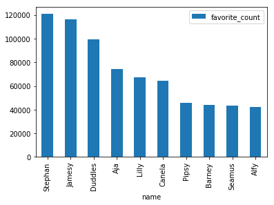

```python
df_name_group.sort_values(['favorite_count'], ascending=False)[:10].plot.bar()
```